# Project2 (1)

## DATA 402 PROJECT 2

## Pollen Grain Image Classification

Dataset Overview: This is a dataset from Kaggle The data can be found here: https://www.kaggle.com/datasets/andrewmvd/pollen-grain-image-classification

## About this data:

The classification of pollen species and types is an important task in many areas like palynology. This is the first annotated image dataset for the Brazilian Savannah pollen types. Article is: Feature Extraction and Machine Learning for the Classification of Brazilian Savannah Pollen Grains. Gonçalves AB, Souza JS, Silva GGd, Cereda MP, Pott A, et al. (2016) Feature Extraction and Machine Learning for the Classification of Brazilian Savannah Pollen Grains. PLOS ONE 11(6): e0157044. https://doi.org/10.1371/journal.pone.0157044

Images by: Image by Thomas Schiewer at Pixabay

## The Objective

To accurately classify many of pollen grain images into their respective classes (no more than 10 clusters) This is important becausee challenges and machine learning skills can be implemented to real-life multi-class datasets like image classifciation for pollen grain. We can use this particular datasein order to display how it might interact with differe semi supervised and nonsupervied ML leaning methods. Howver, the goal is to ultimately be able to optimize clustering and image classification results to get optimal accuracy levels with different ML techniques. (I created this code in Google Colab)

## Clarifications I want to make known

Non-supervised: K-means

Supervised: Artifical Neural Network (For some reason I mixed up terms in the video, but I do know what they mean).

In addition, L2 Regularization on ANN is a form of or extenstion of Supervised learning. Given the context, I counted that as two. The rubric didn't say I could not do this, it just said one should be some kind of artifical net...which I did. If I cannot do this, let me know, but that is my point of view given the class material.

```python
## imports taken from Project 2 example
import pandas as pd
import matplotlib.pyplot as plt
import seaborn as sns

import numpy as np
from sklearn.model_selection import train_test_split
from sklearn.model_selection import cross_val_predict
from sklearn import metrics

from sklearn.naive_bayes import CategoricalNB
import numpy as np

import matplotlib.pyplot as plt
import os
import os.path
from pathlib import Path
import glob
import random
from PIL import Image
import shutil

import tensorflow as tf
from tensorflow import keras
from tensorflow.keras import layers
```

```python
from google.colab import drive
drive.mount ('/content/drive')
```

```python
import os
import pandas as pd
from tensorflow.keras.preprocessing.image import ImageDataGenerator

dataset_path = '/content/drive/My Drive/ProjectB/Pollen/'

#extract file images and their names
data = []
for filename in os.listdir(dataset_path):
    if filename.endswith('.jpg'):  #jpeg images only
        class_name = filename.split('_')[0]
        data.append((filename, class_name))

#df
df = pd.DataFrame(data, columns=['filename', 'class'])

print(df.head())

#rescaling from autocoder from HW 5 "auto coding" mostly for extra credit but for images this helps. It's more augmenation. rescale betwween 1 and 0 HW5
datagen = ImageDataGenerator(rescale=1./255, validation_split=0.2)

#generator to read from the DataFrame from HW 5 "auto coding" Hw 5 (Extra cred) and partt of Hw4
train_generator = datagen.flow_from_dataframe(
    dataframe=df,
    directory=dataset_path,
    x_col='filename',
    y_col='class',
    target_size=(256, 256),
    batch_size=32,
    class_mode='categorical',
    subset='training'
)

validation_generator = datagen.flow_from_dataframe(
    dataframe=df,
    directory=dataset_path,
    x_col='filename',
    y_col='class',
    target_size=(256, 256),
    batch_size=32,
    class_mode='categorical',
    subset='validation'
)
```

```
               filename          class
0  anadenanthera_27.jpg  anadenanthera
1      arecaceae_26.jpg      arecaceae
2      arecaceae_29.jpg      arecaceae
3      arecaceae_08.jpg      arecaceae
4      arecaceae_17.jpg      arecaceae
Found 632 validated image filenames belonging to 91 classes.
Found 158 validated image filenames belonging to 91 classes.
```

```python
data = []
for filename in os.listdir(dataset_path):
    if filename.endswith('.jpg'):
      #Extract class name by splitting
        class_name = filename.split('_')[0].split('-')[0].split(' ')[0]
        class_name = ''.join([i for i in class_name if not i.isdigit()])
        data.append((filename, class_name))


df = pd.DataFrame(data, columns=['filename', 'class'])

# Print the first few rows of the DataFrame to verify
print(df.head())

#rescaling and validation split
datagen = ImageDataGenerator(rescale=1./255, validation_split=0.2)

# Setup the generator to read images and their classes from the DataFrame hw 4&5
train_generator = datagen.flow_from_dataframe(
    dataframe=df,
    directory=dataset_path,
    x_col='filename',
    y_col='class',
    target_size=(256, 256),
    batch_size=32,
    class_mode='categorical',
    subset='training'
)

validation_generator = datagen.flow_from_dataframe(
    dataframe=df,
    directory=dataset_path,
    x_col='filename',
    y_col='class',
    target_size=(256, 256),
    batch_size=32,
    class_mode='categorical',
    subset='validation'
)
```

```
               filename          class
0  anadenanthera_27.jpg  anadenanthera
1      arecaceae_26.jpg      arecaceae
2      arecaceae_29.jpg      arecaceae
3      arecaceae_08.jpg      arecaceae
4      arecaceae_17.jpg      arecaceae
Found 632 validated image filenames belonging to 23 classes.
Found 158 validated image filenames belonging to 23 classes.
```

## Preprocessing

```python
#Function to extract DataFrame from a generator. Combination of HW 4 part a, HW 5 MINST section. Chatgpt did help me point out why errors were happening when my code wasn't working. Turns out I had a problem with 'filename' and accessing the images
def generator_to_df(generator):
    filenames = generator.filenames
    class_labels = [list(generator.class_indices.keys())[cls] for cls in generator.classes]
    return pd.DataFrame({'filename': filenames, 'class_label': class_labels})

#Creating Dataframes and generators, Train and Val from HW 4
train_pollen_df = generator_to_df(train_generator)
test_pollen_df = generator_to_df(validation_generator)

#Again the idea for laying out the content is inspired by Project 2 because I liked the aesthetic (the way train/split data is organized)
def print_train_test_amounts(train_data, test_data):
    print("\nThe Train/Test Split:\n---------------------")
    train_count = len(train_data)
    print("# of Train Images:", train_count)

    test_count = len(test_data)
    print("# of Test Images:", test_count)

    ratio = np.round(train_count / (test_count + train_count), 2)
    print("Train/Test Ratio:", ratio)

print_train_test_amounts(train_pollen_df, test_pollen_df)

#Show the amount in each class. Got from example Project 2 and HW 4
print("\nAmount in Each Pollen Class - Train:\n------------------------------------")
train_class_amts = train_pollen_df['class_label'].value_counts()

for ind, pollen_class, amount in zip(range(len(train_class_amts)), train_class_amts.index, train_class_amts):
    print(f'{ind + 1 :02}.', pollen_class, '\t', amount)

print('......................')
train_count = len(train_pollen_df)
print('Total    \t', train_count)

num_classes = len(train_pollen_df['class_label'].unique())
print(f"\nThere are {num_classes} different pollen classes")
```

```
The Train/Test Split:
---------------------
# of Train Images: 632
# of Test Images: 158
Train/Test Ratio: 0.8

Amount in Each Pollen Class - Train:
------------------------------------
01. urochloa 	 34
02. faramea 	 34
03. cecropia 	 33
04. croton 	 33
05. serjania 	 32
06. senegalia 	 31
07. hyptis 	 30
08. myrcia 	 30
09. qualea 	 30
10. chromolaena 	 30
11. combretum 	 30
12. protium 	 30
13. arrabidaea 	 29
14. mabea 	 29
15. matayba 	 29
16. schinus 	 29
17. mimosa 	 29
18. eucalipto 	 29
19. tridax 	 27
20. dipteryx 	 27
21. syagrus 	 27
......................
Total    	 632

There are 21 different pollen classes
```

## Exploratory Data Analysis

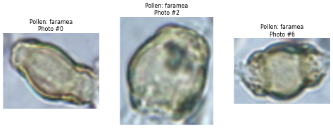

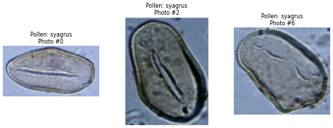

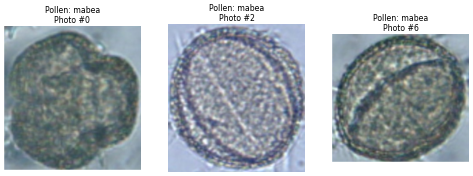

```python
import os
import matplotlib.pyplot as plt
from PIL import Image
import numpy as np

def display_train_image(pollen_class, train_pollen_df, dataset_path):
    if pollen_class in train_pollen_df['class_label'].values:
        #basically means came photos with their classes.
        indexes = [0, 2, 6]
        try:
            display_image_paths = train_pollen_df[train_pollen_df['class_label'] == pollen_class].iloc[indexes, 0]
        except IndexError:
            print(f"Not enough images for class '{pollen_class}'. Showing available ones.")
            display_image_paths = train_pollen_df[train_pollen_df['class_label'] == pollen_class]['filename'].head(len(indexes))

        #Three different classified images
        fig, axs = plt.subplots(1, len(display_image_paths), figsize=(15, 5), dpi = 40)

        for i, display_image_path in enumerate(display_image_paths):
            img_path = os.path.join(dataset_path, display_image_path)
            img = np.array(Image.open(img_path))

            axs[i].imshow(img)
            axs[i].axis('off')
            axs[i].set_title(f"Pollen: {pollen_class}\nPhoto #{indexes[i]}", fontsize=14)

        plt.show()

    else:
         print(f"Pollen class '{pollen_class}' not found in the DataFrame.")

#Again, I'm modeling my images based on Porject 2 to help guide me through the process (it's difficult) but the images clearly show the trained pollen images within their classes and the number of the photo.
display_train_image("faramea", train_pollen_df, dataset_path)
display_train_image("syagrus", train_pollen_df, dataset_path)
display_train_image("mabea", train_pollen_df, dataset_path)
```

```python
import pandas as pd
from sklearn.model_selection import train_test_split
import matplotlib.pyplot as plt

#shuffled and reset train_pollen_df.
train_paths_sampled = train_pollen_df['filename']
train_labels_sampled = train_pollen_df['class_label']

#class distribution in test dataset and filter out classes
class_counts = test_pollen_df['class_label'].value_counts()
valid_classes = class_counts[class_counts >= 2].index
filtered_test_df = test_pollen_df[test_pollen_df['class_label'].isin(valid_classes)]

#This is the same staified split I leaned from the first project. Which I got from 'End_to_End_ML_Advanced' Hw from Dat 402.
val_paths_sampled, test_paths_sampled, val_labels_sampled, test_labels_sampled = train_test_split(
    filtered_test_df['filename'],
    filtered_test_df['class_label'],
    test_size=0.85,
    random_state=42,
    stratify=filtered_test_df['class_label']
)

#Project 2 example. I liked hwo they laid out their results in a seperate line. So I used it for my own dataset.
def print_train_test_amounts(train_data, test_data):
    print("\nThe Train/Test Split:\n---------------------")
    print("# of Train Images:", len(train_data))
    print("# of Test Images:", len(test_data))
    ratio = np.round(len(train_data) / (len(test_data) + len(train_data)), 2)
    print("Train/Test Ratio:", ratio)

print_train_test_amounts(train_paths_sampled, test_paths_sampled)
```

```
The Train/Test Split:
---------------------
# of Train Images: 632
# of Test Images: 133
Train/Test Ratio: 0.83
```

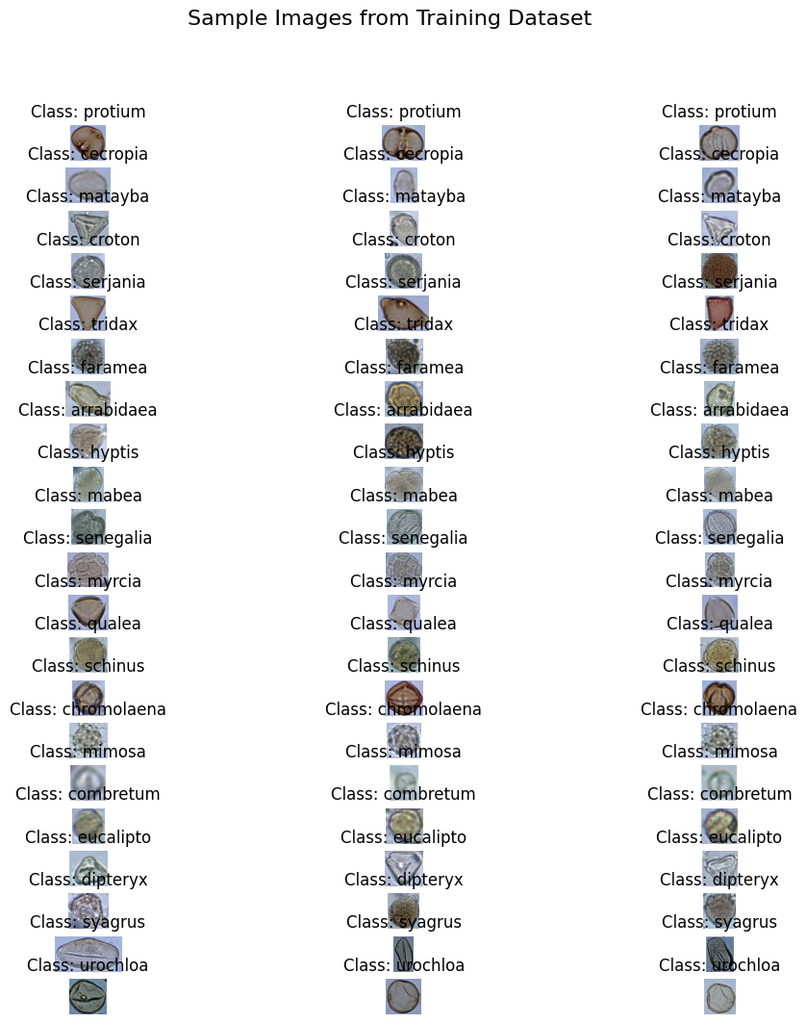

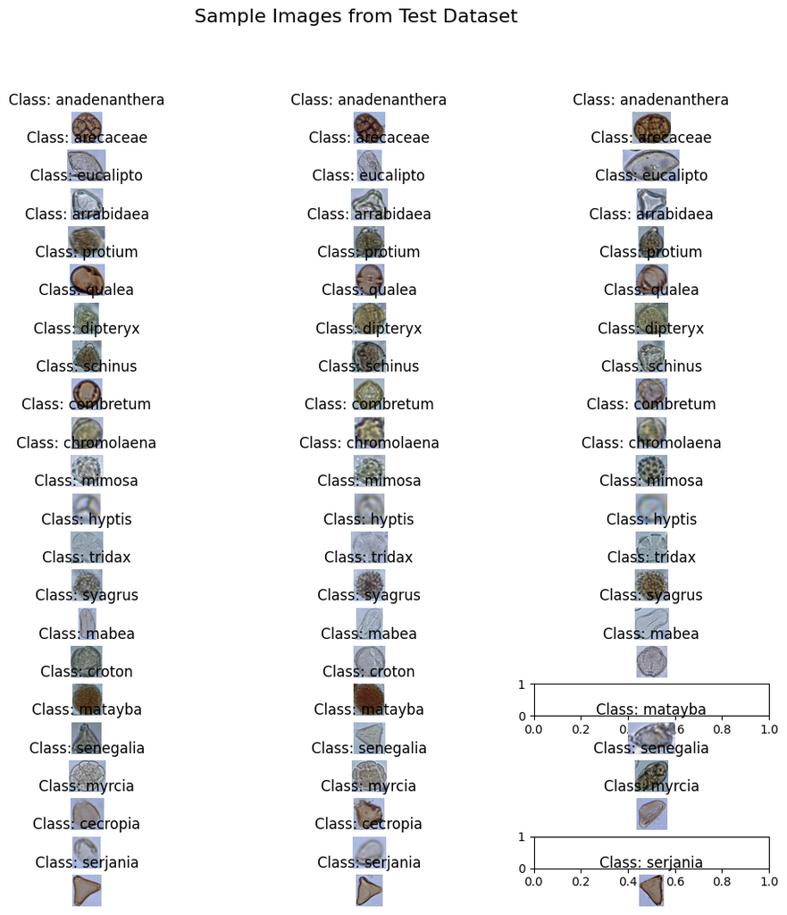

```python
#import os
#from PIL import Image

#I used a combination of the example from Project 2 in the Explanatory Model Section to help me loading the file. Also the training portion was working fine for days and that portion messed up when I started to tweak my code again.
def display_sample_images(paths, labels, dataset_name):
    class_paths = {}
    for path, label in zip(paths, labels):
        if label not in class_paths:
            class_paths[label] = []
        class_paths[label].append(path)

    #displaying the test and train images
    num_classes = len(class_paths)
    num_samples_per_class = 3
    fig, axes = plt.subplots(num_classes, num_samples_per_class, figsize=(12, 12))

    for i, (class_label, paths) in enumerate(class_paths.items()):
        sample_paths = paths[:num_samples_per_class]
        for j, path in enumerate(sample_paths):
            img = Image.open(os.path.join(dataset_path, path))
            axes[i, j].imshow(img)
            axes[i, j].set_title(f"Class: {class_label}")
            axes[i, j].axis('off')

    fig.suptitle(f'Sample Images from {dataset_name} Dataset', fontsize=16)
    plt.show()
#I'm currently taking another begginner Data Modeling class (CIS Business Machine Learning 412). It's basic, but dives into fundamentals a lot so I sometimes ultize that from Hw Week 2 & 4, and fundamental from extra cred HW week 1 in thhis class (DAT 402). And I combine my learning in this class!
display_sample_images(train_paths_sampled, train_labels_sampled, 'Training')

display_sample_images(test_paths_sampled, test_labels_sampled, 'Test')
```